# From Raw Ct to Insights: A qPCR Analysis Tutorial in R

Hamed Abdollahi

2026-04-25

## Overview

This tutorial walks through a complete qPCR analysis pipeline in R — from simulated raw Ct values to statistical testing and publication-ready figures.

**What you will learn:**

- Simulate a realistic qPCR dataset
- Apply ΔCt and ΔΔCt normalization
- Run one-way and two-way ANOVA with Tukey HSD post-hoc
- Perform Principal Component Analysis (PCA) on expression data
- Build violin, boxplot, and interaction plots

**Experimental design used in this tutorial:**

[output not shown]

All data are **simulated** — safe to adapt for any qPCR experiment.

## 1. Setup

```r
# Install any missing packages before loading
required <- c("tidyverse", "ggpubr", "RColorBrewer",
               "factoextra", "FactoMineR", "corrplot",
               "patchwork", "ggridges", "viridis", "gt")

to_install <- required[!required %in% rownames(installed.packages())]
if (length(to_install)) install.packages(to_install)

library(tidyverse)
library(ggpubr)
library(RColorBrewer)
library(factoextra)
library(FactoMineR)
library(corrplot)
library(patchwork)
library(ggridges)
library(viridis)
library(gt)
```

## 2. Simulate qPCR Data

```r
set.seed(42)

# ── Experimental parameters ──────────────────────────────────────────────────
n_samples    <- 40        # total biological samples
n_targets    <- 20        # target genes
hk_gene      <- "GAPDH"  # housekeeping gene
groups       <- c("Control", "Treatment")
tissues      <- c("TypeA", "TypeB")
n_reps       <- 3         # technical replicates per sample

# ── Gene names ───────────────────────────────────────────────────────────────
target_genes <- paste0("Gene_", sprintf("%02d", 1:n_targets))
all_genes    <- c(target_genes, hk_gene)

# ── Sample metadata ──────────────────────────────────────────────────────────
metadata <- tibble(
  Sample_ID = paste0("S", sprintf("%02d", 1:n_samples)),
  Group     = rep(groups,  each = n_samples / 2),
  Tissue    = rep(tissues, times = n_samples / 2)
)

# ── Simulate raw Ct values ───────────────────────────────────────────────────
# Target genes: Ct ~ N(28, 2); Treatment lowers Ct by 1–3 for 8 "responsive" genes
# Housekeeping: Ct ~ N(18, 0.5) — stable across conditions (by design)

simulate_ct <- function(sample_meta, genes, hk) {
  map_dfr(1:nrow(sample_meta), function(i) {
    s <- sample_meta[i, ]

    # 8 genes respond to Treatment (lower Ct = higher expression)
    responsive  <- paste0("Gene_", sprintf("%02d", 1:8))
    effect      <- ifelse(s$Group == "Treatment" & genes %in% responsive,
                          runif(sum(genes %in% responsive), 1, 3), 0)

    # Tissue TypeB adds a small offset for genes 5–12
    tissue_eff  <- ifelse(s$Tissue == "TypeB" & genes %in% paste0("Gene_", sprintf("%02d", 5:12)),
                          runif(sum(genes %in% paste0("Gene_", sprintf("%02d", 5:12))), 0.5, 1.5), 0)

    ct_vals <- rnorm(length(genes), mean = 28, sd = 2) - effect - tissue_eff
    ct_hk   <- rnorm(1, mean = 18, sd = 0.5)

    tibble(
      Sample_ID = s$Sample_ID,
      Gene      = c(genes, hk),
      Ct        = c(ct_vals, ct_hk),
      Replicate = "mean"   # using mean Ct directly for clarity
    )
  })
}

ct_long <- simulate_ct(metadata, target_genes, hk_gene)
ct_wide <- ct_long %>%
  pivot_wider(names_from = Gene, values_from = Ct) %>%
  left_join(metadata, by = "Sample_ID")

cat("Simulated dataset:", nrow(metadata), "samples ×",
    length(all_genes), "genes\n")
```

```
## Simulated dataset: 40 samples × 21 genes
```

```r
glimpse(ct_wide %>% select(Sample_ID, Group, Tissue, Gene_01, Gene_02, GAPDH))
```

```
## Rows: 40
## Columns: 6
## $ Sample_ID <chr> "S01", "S02", "S03", "S04", "S05", "S06", "S07", "S08", "S09…
## $ Group     <chr> "Control", "Control", "Control", "Control", "Control", "Cont…
## $ Tissue    <chr> "TypeA", "TypeB", "TypeA", "TypeB", "TypeA", "TypeB", "TypeA…
## $ Gene_01   <dbl> 30.74192, 27.13906, 26.37721, 27.81963, 29.30070, 33.40378, …
## $ Gene_02   <dbl> 26.87060, 27.48546, 30.88820, 29.24704, 30.78222, 25.27577, …
## $ GAPDH     <dbl> 17.84668, 18.21641, 18.16792, 17.76191, 17.75728, 18.60075, …
```

## 3. ΔCt Normalization

ΔCt subtracts the housekeeping gene Ct from each target gene Ct within the same sample. This corrects for differences in RNA input and cDNA efficiency.

```r
# ── Compute ΔCt for every target gene ────────────────────────────────────────
# ΔCt = Ct_target − Ct_housekeeping
# Lower ΔCt → higher relative expression

delta_ct <- ct_wide %>%
  mutate(across(all_of(target_genes),
                ~ . - GAPDH,
                .names = "dCt_{.col}")) %>%
  select(Sample_ID, Group, Tissue,
         starts_with("dCt_"))

# Rename for clarity: dCt_Gene_01 → Gene_01
colnames(delta_ct) <- gsub("^dCt_", "", colnames(delta_ct))

cat("ΔCt range across all genes and samples:\n")
```

```
## ΔCt range across all genes and samples:
```

```r
delta_ct %>%
  pivot_longer(all_of(target_genes), names_to = "Gene", values_to = "dCt") %>%
  summarise(min = round(min(dCt), 2),
            mean = round(mean(dCt), 2),
            max = round(max(dCt), 2)) %>%
  print()
```

```
## # A tibble: 1 × 3
##     min  mean   max
##   <dbl> <dbl> <dbl>
## 1  2.17   9.4  16.3
```

## 4. ΔΔCt and Fold Change

ΔΔCt compares each sample’s ΔCt to the mean ΔCt of the reference group (here: Control). Fold change = 2^(-ΔΔCt).

```r
# ── Reference: mean ΔCt of Control group per gene ────────────────────────────
control_means <- delta_ct %>%
  filter(Group == "Control") %>%
  summarise(across(all_of(target_genes), mean)) %>%
  pivot_longer(everything(), names_to = "Gene", values_to = "ref_dCt")

# ── Compute ΔΔCt and fold change ─────────────────────────────────────────────
ddct_long <- delta_ct %>%
  pivot_longer(all_of(target_genes),
               names_to = "Gene", values_to = "dCt") %>%
  left_join(control_means, by = "Gene") %>%
  mutate(
    ddCt       = dCt - ref_dCt,              # ΔΔCt
    FoldChange = 2^(-ddCt)                   # relative expression
  )

# Summary: mean fold change per gene per group
fc_summary <- ddct_long %>%
  group_by(Gene, Group) %>%
  summarise(mean_FC = mean(FoldChange), .groups = "drop") %>%
  pivot_wider(names_from = Group, values_from = mean_FC) %>%
  mutate(FC_TreatvsControl = round(Treatment / Control, 2)) %>%
  arrange(desc(FC_TreatvsControl))

cat("Top 5 upregulated genes in Treatment vs Control:\n")
```

```
## Top 5 upregulated genes in Treatment vs Control:
```

```r
head(fc_summary, 5)
```

| Gene | Control | Treatment | FC_TreatvsControl |
| --- | --- | --- | --- |
| Gene_04 | 2.036485 | 22.61409 | 11.10 |
| Gene_01 | 1.884974 | 19.27382 | 10.22 |
| Gene_06 | 1.947362 | 12.03574 | 6.18 |
| Gene_05 | 1.980647 | 10.88711 | 5.50 |
| Gene_02 | 2.162245 | 8.68503 | 4.02 |

## 5. Descriptive Statistics

```r
# ── Summary stats: ΔCt by Group × Tissue ─────────────────────────────────────
dct_stats <- ddct_long %>%
  group_by(Gene, Group, Tissue) %>%
  summarise(
    n      = n(),
    mean   = round(mean(dCt),   2),
    sd     = round(sd(dCt),     2),
    se     = round(sd / sqrt(n), 3),
    median = round(median(dCt), 2),
    .groups = "drop"
  )

# Print a tidy table for the first 5 genes as a preview
dct_stats %>%
  filter(Gene %in% paste0("Gene_0", 1:5)) %>%
  gt() %>%
  tab_header(title    = "Descriptive statistics — ΔCt",
             subtitle = "First 5 genes, by Group × Tissue") %>%
  fmt_number(columns = c(mean, sd, se, median), decimals = 2) %>%
  tab_style(
    style = cell_fill(color = "#EAF3DE"),
    locations = cells_body(rows = Group == "Treatment")
  )
```

Descriptive statistics — ΔCt

First 5 genes, by Group × Tissue

| Gene | Group | Tissue | n | mean | sd | se | median |
| --- | --- | --- | --- | --- | --- | --- | --- |
| Gene_01 | Control | TypeA | 10 | 10.04 | 1.50 | 0.47 | 10.07 |
| Gene_01 | Control | TypeB | 10 | 10.05 | 2.45 | 0.78 | 9.20 |
| Gene_01 | Treatment | TypeA | 10 | 8.06 | 2.40 | 0.76 | 8.46 |
| Gene_01 | Treatment | TypeB | 10 | 7.47 | 2.48 | 0.78 | 8.05 |
| Gene_02 | Control | TypeA | 10 | 10.18 | 1.97 | 0.62 | 10.08 |
| Gene_02 | Control | TypeB | 10 | 9.71 | 2.06 | 0.65 | 9.90 |
| Gene_02 | Treatment | TypeA | 10 | 8.33 | 2.60 | 0.82 | 8.06 |
| Gene_02 | Treatment | TypeB | 10 | 8.07 | 2.04 | 0.65 | 8.09 |
| Gene_03 | Control | TypeA | 10 | 10.31 | 2.60 | 0.82 | 10.49 |
| Gene_03 | Control | TypeB | 10 | 10.83 | 2.38 | 0.75 | 11.22 |
| Gene_03 | Treatment | TypeA | 10 | 8.86 | 1.19 | 0.38 | 9.11 |
| Gene_03 | Treatment | TypeB | 10 | 9.35 | 2.83 | 0.90 | 8.43 |
| Gene_04 | Control | TypeA | 10 | 10.20 | 1.47 | 0.47 | 10.03 |
| Gene_04 | Control | TypeB | 10 | 9.73 | 2.17 | 0.69 | 9.60 |
| Gene_04 | Treatment | TypeA | 10 | 8.26 | 2.38 | 0.75 | 7.97 |
| Gene_04 | Treatment | TypeB | 10 | 6.86 | 2.79 | 0.88 | 7.23 |
| Gene_05 | Control | TypeA | 10 | 10.26 | 1.49 | 0.47 | 10.24 |
| Gene_05 | Control | TypeB | 10 | 8.39 | 1.49 | 0.47 | 8.24 |
| Gene_05 | Treatment | TypeA | 10 | 8.95 | 2.94 | 0.93 | 10.17 |
| Gene_05 | Treatment | TypeB | 10 | 6.64 | 1.80 | 0.57 | 6.53 |

## 6. Statistical Testing

### 6.1 One-Way ANOVA: Group effect

```r
# ── One-way ANOVA: does expression differ by Group? ───────────────────────────
# Run for every gene; collect F-statistic and p-value

anova_group <- map_dfr(target_genes, function(g) {
  d   <- delta_ct %>% select(Group, Tissue, value = all_of(g))
  fit <- aov(value ~ Group, data = d)
  s   <- summary(fit)[[1]]
  tibble(Gene    = g,
         F_value = round(s$`F value`[1], 3),
         p_value = round(s$`Pr(>F)`[1],  4))
}) %>%
  mutate(q_value = round(p.adjust(p_value, method = "BH"), 4),
         Significant = q_value < 0.05) %>%
  arrange(p_value)

cat("Significant genes (BH q < 0.05):", sum(anova_group$Significant), "\n")
```

```
## Significant genes (BH q < 0.05): 4
```

```r
head(anova_group, 10)
```

| Gene | F_value | p_value | q_value | Significant |
| --- | --- | --- | --- | --- |
| Gene_06 | 19.650 | 0.0001 | 0.0020 | TRUE |
| Gene_07 | 11.353 | 0.0017 | 0.0110 | TRUE |
| Gene_04 | 11.317 | 0.0018 | 0.0110 | TRUE |
| Gene_01 | 10.759 | 0.0022 | 0.0110 | TRUE |
| Gene_02 | 6.666 | 0.0138 | 0.0552 | FALSE |
| Gene_05 | 4.659 | 0.0373 | 0.1243 | FALSE |
| Gene_03 | 4.082 | 0.0504 | 0.1440 | FALSE |
| Gene_18 | 2.377 | 0.1314 | 0.3285 | FALSE |
| Gene_08 | 1.873 | 0.1792 | 0.3982 | FALSE |
| Gene_15 | 1.675 | 0.2034 | 0.4068 | FALSE |

### 6.2 Two-Way ANOVA: Group × Tissue interaction

```r
# ── Two-way ANOVA: Group × Tissue interaction ─────────────────────────────────
anova_interaction <- map_dfr(target_genes, function(g) {
  d   <- delta_ct %>% select(Group, Tissue, value = all_of(g))
  fit <- aov(value ~ Group * Tissue, data = d)
  s   <- summary(fit)[[1]]
  tibble(
    Gene              = g,
    F_Group           = round(s$`F value`[1], 3),
    p_Group           = round(s$`Pr(>F)`[1],  4),
    F_Tissue          = round(s$`F value`[2], 3),
    p_Tissue          = round(s$`Pr(>F)`[2],  4),
    F_Interaction     = round(s$`F value`[3], 3),
    p_Interaction     = round(s$`Pr(>F)`[3],  4)
  )
}) %>%
  arrange(p_Interaction)

cat("Genes with significant Group × Tissue interaction (p < 0.05):",
    sum(anova_interaction$p_Interaction < 0.05, na.rm = TRUE), "\n")
```

```
## Genes with significant Group × Tissue interaction (p < 0.05): 2
```

```r
head(anova_interaction, 8)
```

| Gene | F_Group | p_Group | F_Tissue | p_Tissue | F_Interaction | p_Interaction |
| --- | --- | --- | --- | --- | --- | --- |
| Gene_12 | 0.001 | 0.9791 | 1.353 | 0.2525 | 15.170 | 0.0004 |
| Gene_06 | 22.020 | 0.0000 | 0.146 | 0.7046 | 6.436 | 0.0157 |
| Gene_14 | 0.070 | 0.7934 | 1.037 | 0.3153 | 3.372 | 0.0746 |
| Gene_17 | 0.666 | 0.4200 | 0.422 | 0.5200 | 1.930 | 0.1733 |
| Gene_10 | 0.262 | 0.6119 | 0.039 | 0.8442 | 1.445 | 0.2371 |
| Gene_09 | 0.028 | 0.8675 | 3.484 | 0.0701 | 0.845 | 0.3641 |
| Gene_13 | 0.612 | 0.4392 | 0.069 | 0.7946 | 0.524 | 0.4739 |
| Gene_11 | 1.585 | 0.2162 | 3.668 | 0.0634 | 0.510 | 0.4799 |

### 6.3 Tukey HSD Post-Hoc

```r
# ── Tukey HSD for the most significant gene ───────────────────────────────────
top_gene <- anova_group$Gene[1]
cat("Running Tukey HSD for:", top_gene, "\n\n")
```

```
## Running Tukey HSD for: Gene_06
```

```r
d_top <- delta_ct %>%
  mutate(Group_Tissue = interaction(Group, Tissue)) %>%
  select(Group_Tissue, value = all_of(top_gene))

tukey_fit    <- aov(value ~ Group_Tissue, data = d_top)
tukey_result <- TukeyHSD(tukey_fit)
print(tukey_result)
```

```
##   Tukey multiple comparisons of means
##     95% family-wise confidence level
##
## Fit: aov(formula = value ~ Group_Tissue, data = d_top)
##
## $Group_Tissue
##                                      diff        lwr        upr     p adj
## Treatment.TypeA-Control.TypeA   -1.135603 -3.1421643  0.8709585 0.4340217
## Control.TypeB-Control.TypeA      1.135190 -0.8713716  3.1417512 0.4343405
## Treatment.TypeB-Control.TypeA   -2.673444 -4.6800051 -0.6668824 0.0051988
## Control.TypeB-Treatment.TypeA    2.270793  0.2642314  4.2773541 0.0213778
## Treatment.TypeB-Treatment.TypeA -1.537841 -3.5444022  0.4687205 0.1843057
## Treatment.TypeB-Control.TypeB   -3.808634 -5.8151949 -1.8020722 0.0000610
```

## 7. Visualization

### 7.1 Mean ± SE Interaction Plot

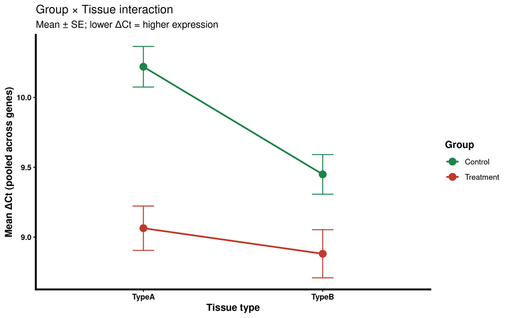

```r
# ── Pooled ΔCt summary across all genes ───────────────────────────────────────
pooled_summary <- ddct_long %>%
  group_by(Group, Tissue) %>%
  summarise(
    mean = mean(dCt),
    se   = sd(dCt) / sqrt(n()),
    .groups = "drop"
  )

ggplot(pooled_summary,
       aes(x = factor(Tissue, levels = c("TypeA", "TypeB")),
           y = mean, color = Group, group = Group)) +
  geom_point(size = 3.5) +
  geom_line(linewidth = 0.9) +
  geom_errorbar(aes(ymin = mean - se, ymax = mean + se), width = 0.12) +
  scale_color_manual(values = c("Control" = "#1E8449", "Treatment" = "#C0392B")) +
  labs(x = "Tissue type", y = "Mean ΔCt (pooled across genes)",
       title = "Group × Tissue interaction",
       subtitle = "Mean ± SE; lower ΔCt = higher expression") +
  theme_classic() +
  theme(axis.line  = element_line(linewidth = 1),
        axis.text  = element_text(face = "bold"),
        axis.title = element_text(face = "bold"),
        legend.title = element_text(face = "bold"))
```

### 7.2 Violin + Boxplot per Group

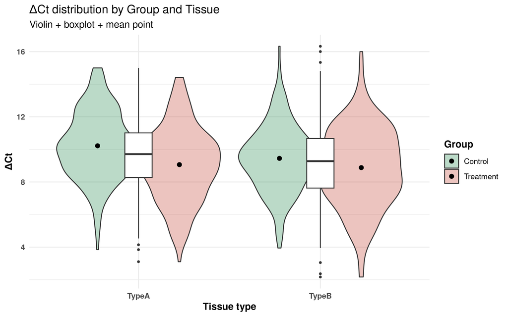

```r
# ── Long-format ΔCt for all genes ────────────────────────────────────────────
dct_long_plot <- delta_ct %>%
  pivot_longer(all_of(target_genes),
               names_to = "Gene", values_to = "dCt")

ggplot(dct_long_plot, aes(x = Tissue, y = dCt, fill = Group)) +
  geom_violin(alpha = 0.3, position = position_dodge(0.9), scale = "width") +
  geom_boxplot(width = 0.15, position = position_dodge(0.9),
               fill  = "white", outlier.size = 0.8) +
  stat_summary(fun = mean, geom = "point", size = 2,
               position = position_dodge(0.9), color = "black") +
  scale_fill_manual(values = c("Control" = "#1E8449", "Treatment" = "#C0392B")) +
  labs(x = "Tissue type", y = "ΔCt",
       title = "ΔCt distribution by Group and Tissue",
       subtitle = "Violin + boxplot + mean point") +
  theme_minimal() +
  theme(axis.text  = element_text(face = "bold"),
        axis.title = element_text(face = "bold"),
        legend.title = element_text(face = "bold"))
```

### 7.3 Volcano-Style Fold Change Plot

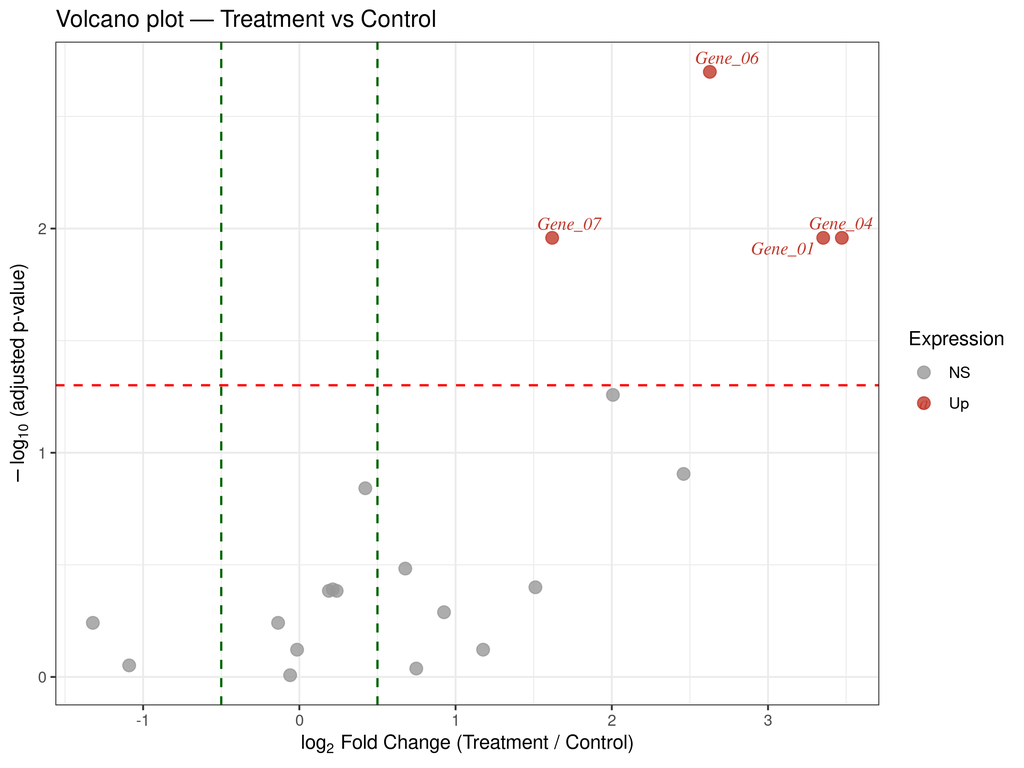

```r
# ── Gene-level fold change vs significance ────────────────────────────────────
volcano_df <- fc_summary %>%
  left_join(anova_group %>% select(Gene, q_value), by = "Gene") %>%
  mutate(
    log2FC    = log2(FC_TreatvsControl),
    neg_log10 = -log10(q_value),
    Status    = case_when(
      q_value < 0.05 & log2FC >  0.5 ~ "Up",
      q_value < 0.05 & log2FC < -0.5 ~ "Down",
      TRUE                            ~ "NS"
    )
  )

ggplot(volcano_df, aes(x = log2FC, y = neg_log10, color = Status)) +
  geom_point(size = 3, alpha = 0.8) +
  geom_vline(xintercept = c(-0.5, 0.5), linetype = "dashed",
             color = "darkgreen", linewidth = 0.6) +
  geom_hline(yintercept = -log10(0.05), linetype = "dashed",
             color = "red", linewidth = 0.6) +
  ggrepel::geom_text_repel(
    data = filter(volcano_df, Status != "NS"),
    aes(label = Gene), size = 3.5, max.overlaps = 15,
    fontface = "italic", family = "serif"
  ) +
  scale_color_manual(values = c("Up" = "#C0392B", "Down" = "#1565AC", "NS" = "grey60")) +
  labs(x     = expression(log[2]~"Fold Change (Treatment / Control)"),
       y     = expression(-log[10]~"(adjusted p-value)"),
       title = "Volcano plot — Treatment vs Control",
       color = "Expression") +
  theme_bw()
```

### 7.4 Density Ridgeline Plot

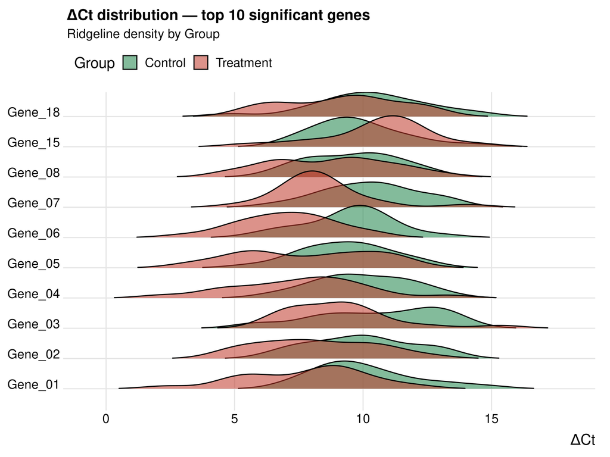

```r
# ── Ridgeline: ΔCt distribution per gene, coloured by Group ──────────────────
# Select the 10 most significant genes for readability
top10 <- anova_group$Gene[1:10]

dct_long_plot %>%
  filter(Gene %in% top10) %>%
  ggplot(aes(x = dCt, y = Gene, fill = Group)) +
  geom_density_ridges(alpha = 0.55, scale = 1.2,
                      rel_min_height = 0.01) +
  scale_fill_manual(values = c("Control" = "#1E8449", "Treatment" = "#C0392B")) +
  labs(x = "ΔCt", y = NULL,
       title = "ΔCt distribution — top 10 significant genes",
       subtitle = "Ridgeline density by Group") +
  theme_ridges() +
  theme(legend.position = "top")
```

### 7.5 Heatmap-Style Tile Plot

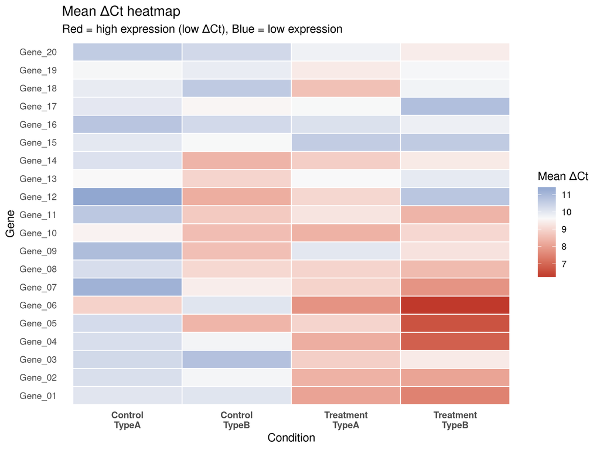

```r
# ── Mean ΔCt heatmap: Gene × Group × Tissue ───────────────────────────────────
heatmap_df <- dct_long_plot %>%
  group_by(Gene, Group, Tissue) %>%
  summarise(mean_dCt = mean(dCt), .groups = "drop") %>%
  mutate(condition = paste0(Group, "\n", Tissue))

ggplot(heatmap_df, aes(x = condition, y = Gene, fill = mean_dCt)) +
  geom_tile(color = "white", linewidth = 0.4) +
  scale_fill_gradient2(
    low      = "#C0392B",
    mid      = "#F9F9F9",
    high     = "#1565AC",
    midpoint = median(heatmap_df$mean_dCt),
    name     = "Mean ΔCt"
  ) +
  labs(x = "Condition", y = "Gene",
       title = "Mean ΔCt heatmap",
       subtitle = "Red = high expression (low ΔCt), Blue = low expression") +
  theme_minimal() +
  theme(axis.text.x = element_text(face = "bold"),
        panel.grid  = element_blank())
```

## 8. PCA of Gene Expression

PCA summarises the 20-gene expression profiles of each sample into a low-dimensional space. Samples clustering by Group or Tissue confirm that the gene panel captures relevant biological variation.

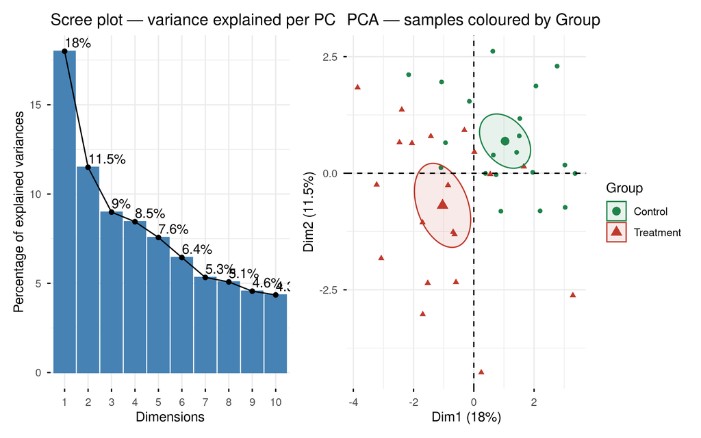

```r
# ── PCA input: samples × genes (ΔCt matrix) ───────────────────────────────────
pca_matrix <- delta_ct %>%
  select(all_of(target_genes)) %>%
  as.data.frame()

rownames(pca_matrix) <- paste0(delta_ct$Sample_ID, "_",
                               delta_ct$Group, "_", delta_ct$Tissue)

pca_result <- PCA(pca_matrix, scale.unit = TRUE, ncp = 10, graph = FALSE)

# ── Scree plot ────────────────────────────────────────────────────────────────
p_scree <- fviz_eig(pca_result, addlabels = TRUE, ncp = 10,
                    ggtheme = theme_minimal(),
                    title   = "Scree plot — variance explained per PC")

# ── Sample map coloured by Group ──────────────────────────────────────────────
group_col <- delta_ct$Group

p_ind <- fviz_pca_ind(
  pca_result,
  geom.ind    = "point",
  col.ind     = group_col,
  palette     = c("Control" = "#1E8449", "Treatment" = "#C0392B"),
  addEllipses = TRUE,
  ellipse.type = "confidence",
  repel       = TRUE,
  legend.title = "Group",
  title        = "PCA — samples coloured by Group"
)

p_scree + p_ind
```

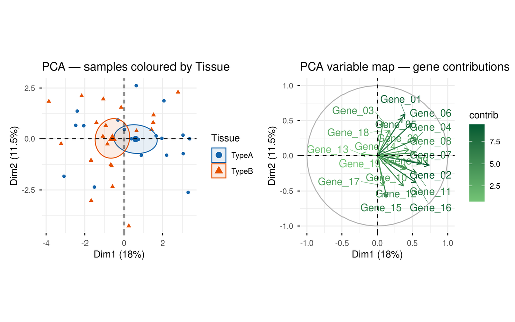

```r
# ── Sample map coloured by Tissue ─────────────────────────────────────────────
tissue_col <- delta_ct$Tissue

p_tissue <- fviz_pca_ind(
  pca_result,
  geom.ind    = "point",
  col.ind     = tissue_col,
  palette     = c("TypeA" = "#1565AC", "TypeB" = "#E65100"),
  addEllipses = TRUE,
  ellipse.type = "confidence",
  repel        = TRUE,
  legend.title = "Tissue",
  title        = "PCA — samples coloured by Tissue"
)

# ── Variable (gene) map ───────────────────────────────────────────────────────
p_var <- fviz_pca_var(
  pca_result,
  col.var    = "contrib",
  gradient.cols = c("#74C476", "#005A32"),
  repel      = TRUE,
  title      = "PCA variable map — gene contributions"
)

p_tissue + p_var
```

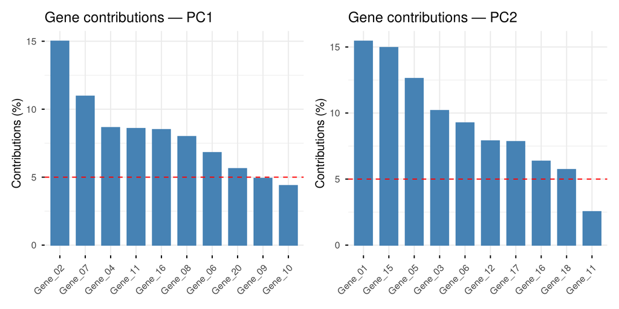

```r
# ── Top gene contributions to PC1 and PC2 ────────────────────────────────────
p_c1 <- fviz_contrib(pca_result, choice = "var", axes = 1, top = 10) +
  ggtitle("Gene contributions — PC1")
p_c2 <- fviz_contrib(pca_result, choice = "var", axes = 2, top = 10) +
  ggtitle("Gene contributions — PC2")

p_c1 + p_c2
```

## 9. Export Results

```r
dir.create("results", showWarnings = FALSE)

# ΔCt normalized data
write.csv(delta_ct,       "results/delta_ct_normalized.csv",  row.names = FALSE)

# ΔΔCt and fold change
write.csv(ddct_long,      "results/ddct_fold_change.csv",     row.names = FALSE)

# ANOVA results
write.csv(anova_group,    "results/anova_group_effect.csv",   row.names = FALSE)
write.csv(anova_interaction, "results/anova_interaction.csv", row.names = FALSE)

# Fold change summary
write.csv(fc_summary,     "results/fold_change_summary.csv",  row.names = FALSE)

cat("Results exported to results/\n")
```

```
## Results exported to results/
```

## Key Formulas Reference

$$\Delta Ct = Ct_{target} -
Ct_{housekeeping}$$

$$\Delta \Delta Ct = \Delta Ct_{sample} -
\Delta Ct_{calibrator}$$

$$\text{Fold Change} = 2^{-\Delta\Delta
Ct}$$

**Interpretation guide:**

| ΔCt | Expression level |
| --- | --- |
| Low (e.g. 2–5) | High expression |
| Medium (e.g. 8–12) | Moderate expression |
| High (e.g. >15) | Low / absent expression |

*This tutorial uses simulated data. Adapt the simulation parameters in Section 2 to match your own experimental design.*